# Header

**Employee Turnover Prediction**

- Group No : 32
- Group Members
  - EG/2021/4568 - Jathurshan T.
  - EG/2021/4390 - Ahamed N.F.F.
- Dataset link : https://www.kaggle.com/datasets/giripujar/hr-analytics/data
- Chosen algorithms : Random Forest Classifier, K-Nearest Neighbor Classifier

# Introduction

Employee turnover is the number of employees who leave a company over a specific period of time. Employee turnover prediction is a critical task for organizations to understand the factors contributing to employee attrition and take proactive measures to improve retention. In this project, we present an analysis of employee turnover using a dataset that captures key factors associated with employees' tenure at a company. The dataset includes various attributes that may influence an employee's decision to leave the company, such as their satisfaction level, performance evaluations, work conditions, and compensation.

Our dataset used for this analysis contains the following features:

1. **Satisfaction Level**: A numerical value representing the employee's satisfaction with their job. Lower satisfaction levels have been found to correlate with higher turnover rates.
2. **Last Evaluation:** A numerical value reflecting the most recent performance evaluation score. A lower evaluation score may indicate dissatisfaction or underperformance, potentially leading to attrition.
3. **Number of Projects:** The number of projects an employee is involved in. A higher workload could lead to stress or burnout, which could influence turnover.
4. **Average Monthly Hours:** The average number of hours worked per month. Excessive working hours can contribute to employee burnout and job dissatisfaction, increasing the likelihood of turnover.
5. **Time Spent at Company:** The number of years the employee has been with the company. Employees with longer tenures may have a stronger connection to the organization, while those with shorter tenures might be more prone to leaving.
6. **Work Accident:** A binary indicator of whether the employee had a work-related accident. Such incidents can lead to dissatisfaction or resignation due to perceived safety concerns.
7. **Promotion in the Last 5 Years:** A binary feature indicating whether the employee received a promotion in the last five years. Employees who have not received promotions might feel underappreciated or stagnant, increasing the likelihood of leaving the company.
8. **Department:** The department in which the employee works (e.g., sales, technical, etc.). Certain departments may experience higher turnover rates based on organizational dynamics or job roles.
9. **Salary:** The employee's salary level, categorized as low, medium, or high. Salary disparities can be a significant factor in employee dissatisfaction and turnover.

The target variable in this dataset is "left", which indicates whether the employee has left the company (1) or not (0). The goal of this machine learning project is to use the available features to predict whether an employee is likely to leave the company.

Through this analysis, we aim to uncover patterns and trends that contribute to employee attrition, which can inform strategies for improving employee retention, job satisfaction, and overall organizational performance.

# Literature Survey

Employee turnover is a widely studied phenomenon in human resources (HR) management, as it can have significant financial and operational implications for organizations. A comprehensive body of literature has emerged that investigates the various factors influencing employee attrition. Understanding these factors is crucial for predicting turnover and devising strategies to mitigate it. Below, we review key studies that explore the determinants of employee turnover, focusing on aspects relevant to the dataset used in this analysis.

1. **Job Satisfaction and Employee Turnover**

A well-established factor influencing employee turnover is job satisfaction. According to Mobley (1977), dissatisfaction with one’s job is a primary driver of voluntary turnover. Employees who report low job satisfaction tend to be less committed to their organization, which increases the likelihood of them leaving. In the dataset, satisfaction_level serves as a key indicator of employee contentment. Previous studies have shown a negative correlation between satisfaction and turnover, where lower satisfaction levels correlate with a higher probability of employees leaving the organization (Tett & Meyer, 1993).

2. **Performance Evaluation and Turnover**

Employee performance evaluations play an important role in shaping both employee satisfaction and turnover decisions. Judge & Bono (2001) highlight that poor performance evaluations may lead to feelings of underappreciation and dissatisfaction, potentially prompting employees to seek alternative employment. In the dataset, last_evaluation reflects recent performance assessments, and research suggests that employees with lower evaluation scores are more likely to leave an organization, especially if they perceive no opportunity for growth or promotion (Riley, 2001).

3. **Workload and Burnout**

Excessive workload is another critical factor influencing turnover. The number of projects an employee is involved in and the average monthly hours worked are indicators of workload. Studies by Maslach & Leiter (1997) and Freudenberger (1974) indicate that high workloads and long working hours are linked to job burnout, stress, and eventually turnover. Employees who are overburdened with tasks may experience fatigue, decreased productivity, and lower job satisfaction, increasing their likelihood of leaving the company.

4. **Tenure and Employee Retention**

The time spent at the company is an important predictor of turnover. Employees with longer tenures are often more committed and integrated into the organization, while those with shorter tenures may feel disconnected or face challenges adjusting to the organizational culture. Hom & Griffeth (1995) found that tenure negatively correlates with turnover, where employees with more years of service tend to stay longer. However, Allen et al. (2010) suggest that after a certain point, tenure can have a diminishing effect on retention, particularly if employees perceive limited career advancement opportunities.

5. **Promotion and Career Development**

Promotion opportunities are strongly linked to employee retention. Mobley (1977) found that employees who were not promoted within a reasonable timeframe were more likely to leave, as they perceived a lack of career progression. In the dataset, promotion_last_5years serves as an indicator of whether an employee has received a promotion, which is a critical factor in retention decisions. Employees who feel stagnant in their careers or have not been rewarded for their contributions may seek opportunities elsewhere.

6. **Workplace Safety and Accidents**

The occurrence of a work accident has been shown to influence employee turnover, particularly in hazardous work environments. Kurtz (2007) suggests that employees who experience workplace accidents or witness such incidents may feel insecure about their safety, leading to dissatisfaction and increased turnover. Employees who suffer from work-related injuries or who perceive their work environment as unsafe may be more inclined to leave the organization.

7. **Department and Turnover**

Turnover rates may vary significantly between different departments within an organization. For instance, departments with more stressful or demanding roles, such as sales or customer service, may have higher turnover rates compared to departments with less demanding work. Kacmar et al. (2009) highlight that organizational factors such as departmental work culture, leadership, and job role impact employee satisfaction and turnover rates. The Department feature in the dataset reflects these organizational dynamics, offering insight into the variance in turnover across different business units.

8. **Salary and Employee Retention**

Lastly, salary is a fundamental factor in employee retention. Employees who feel they are underpaid relative to their peers or the market are more likely to seek employment elsewhere. Holtom et al. (2008) found that salary dissatisfaction is one of the strongest predictors of voluntary turnover. The dataset categorizes employees into three salary levels: low, medium, and high. Research suggests that employees in lower salary brackets are generally more prone to turnover, especially if they perceive better compensation opportunities in other organizations.

Summary of Literature The literature on employee turnover emphasizes several key predictors: job satisfaction, performance evaluations, workload, tenure, promotion opportunities, work accidents, departmental factors, and salary. The dataset used in this study captures many of these dimensions, providing a rich basis for predicting employee turnover. By analyzing these factors, organizations can better understand the underlying causes of turnover and take steps to retain valuable employees, ultimately improving overall organizational performance and reducing the costs associated with employee attrition.

# Dataset Description

The dataset used in this project consists of employee-related information, which includes various factors that may influence an employee’s decision to leave the company. It is structured with several features representing both numerical and categorical data, along with a target variable that indicates whether an employee has left the company. Here we include detailed description of the dataset’s attributes:

1. **Satisfaction Level (satisfaction_level)**

Type: Continuous (numerical)  
Description: This feature represents the employee's satisfaction with their job. The values range from 0 to 1, where 0 represents extremely low satisfaction and 1 indicates the highest possible level of satisfaction. Job satisfaction has been widely recognized as a key determinant in predicting employee turnover. Employees with lower satisfaction levels are generally more likely to leave the company.  
Example: 0.38, 0.80, 0.11, etc.

2. **Last Evaluation (last_evaluation)**

Type: Continuous (numerical)  
Description: This feature reflects the most recent performance evaluation score for the employee. It ranges from 0 to 1, with higher values indicating better performance evaluations. A low evaluation score may correlate with employee dissatisfaction or a lack of career progression, which could influence the likelihood of leaving the company.  
Example: 0.53, 0.86, 0.88, etc.

3. **Number of Projects (number_project)**

Type: Discrete (numerical)  
Description: The number of projects the employee is working on. This feature provides insight into the employee’s workload. A high number of projects might indicate a heavy workload, which can lead to stress and burnout, increasing the likelihood of turnover.  
Example: 2, 5, 7, etc.

4. **Average Monthly Hours (average_montly_hours)**

Type: Continuous (numerical)  
Description: The average number of hours the employee works per month. This feature can be indicative of work-life balance. High monthly hours could lead to burnout, dissatisfaction, and eventually higher turnover rates.  
Example: 157, 262, 272, etc.

5. **Time Spent at Company (time_spend_company)**

Type: Discrete (numerical)  
Description: This feature represents the number of years the employee has been with the company. Employees with longer tenures may be more likely to stay with the organization, as they have established relationships and are more familiar with the organizational culture. On the other hand, employees with shorter tenures may be more inclined to leave, especially if they perceive fewer growth opportunities.  
Example: 3, 6, 4, etc.

6. **Work Accident (Work_accident)**

Type: Categorical (binary)  
Description: A binary variable that indicates whether the employee has had a work-related accident (1 = Yes, 0 = No). Work accidents can lead to dissatisfaction and concerns regarding workplace safety, both of which are linked to higher turnover rates.  
Example: 0, 0, 0, etc.

7. **Left (left)**

Type: Categorical (binary, target variable)  
Description: The target variable for this classification task, indicating whether an employee has left the company (1 = Yes, 0 = No). This is the primary variable we aim to predict using the other features. The goal is to determine the factors that are most strongly associated with employees leaving the company.  
Example: 1, 1, 1, etc.

8. **Promotion in the Last 5 Years (promotion_last_5years)**

Type: Categorical (binary)  
Description: This feature indicates whether the employee received a promotion in the last five years (1 = Yes, 0 = No). Lack of career advancement can lead to dissatisfaction and contribute to turnover, especially if employees feel their contributions are not being recognized.  
Example: 0, 0, 0, etc.

9. **Department (Department)**

Type: Categorical (nominal)  
Description: This feature indicates the department in which the employee works. Different departments may experience varying levels of turnover due to differences in job roles, work culture, and job satisfaction. For example, sales departments may have higher turnover compared to administrative or technical departments.  
Example: sales, technical, support, etc.

10. **Salary (salary)**

Type: Categorical (nominal)  
Description: This feature categorizes the employee’s salary level as one of three categories: low, medium, or high. Employees who feel they are underpaid relative to their peers or the market may be more likely to leave. Therefore, salary plays a significant role in retention strategies.  
Example: low, medium, high

Summary of the Dataset  
Number of Rows: 14,999 employees  
Number of Columns: 10 features (including the target variable)  
Target Variable: left (binary classification: 0 = Not left, 1 = Left)  
Types of Features:

- Numerical (Continuous & Discrete): satisfaction_level, last_evaluation, number_project, average_montly_hours, time_spend_company
- Categorical (Binary & Nominal): Work_accident, promotion_last_5years, Department, salary, and left (target)

The dataset contains a variety of factors that contribute to employee turnover, from job satisfaction and work conditions to career development opportunities and compensation. By analyzing these attributes, we can build a predictive model to forecast employee attrition and provide actionable insights for improving retention strategies.

# Exploratory Data Analysis

```python
# Import libraries
import matplotlib.pyplot as plt
import pandas as pd
import seaborn as sns
import numpy as np
```

```python
import warnings
warnings.filterwarnings('ignore')
```

```python
# Import dataset
df = pd.read_csv('HR_comma_sep.csv')
```

```python
# preview the dataset
df.head()
```

|  | satisfaction_level | last_evaluation | number_project | average_montly_hours | time_spend_company | Work_accident | left | promotion_last_5years | Department | salary |
| --- | --- | --- | --- | --- | --- | --- | --- | --- | --- | --- |
| 0 | 0.38 | 0.53 | 2 | 157 | 3 | 0 | 1 | 0 | sales | low |
| 1 | 0.80 | 0.86 | 5 | 262 | 6 | 0 | 1 | 0 | sales | medium |
| 2 | 0.11 | 0.88 | 7 | 272 | 4 | 0 | 1 | 0 | sales | medium |
| 3 | 0.72 | 0.87 | 5 | 223 | 5 | 0 | 1 | 0 | sales | low |
| 4 | 0.37 | 0.52 | 2 | 159 | 3 | 0 | 1 | 0 | sales | low |

```python
df.shape
```

```
(14999, 10)
```

We can see that there are **14999 instances** and **10 variables** in the data set.

```python
col_names = df.columns
col_names
```

```
Index(['satisfaction_level', 'last_evaluation', 'number_project',
       'average_montly_hours', 'time_spend_company', 'Work_accident', 'left',
       'promotion_last_5years', 'Department', 'salary'],
      dtype='object')
```

Here We can celarly see that some column names staring with uppercase letters. So, to standardize and maintain consistency in column naming conventions, we can change these uppercase columns to lowercase.

```python
df.columns = df.columns.str.lower()
df.columns
```

```
Index(['satisfaction_level', 'last_evaluation', 'number_project',
       'average_montly_hours', 'time_spend_company', 'work_accident', 'left',
       'promotion_last_5years', 'department', 'salary'],
      dtype='object')
```

```python
# view summary of dataset
df.info()
```

```
<class 'pandas.core.frame.DataFrame'>
RangeIndex: 14999 entries, 0 to 14998
Data columns (total 10 columns):
 #   Column                 Non-Null Count  Dtype
---  ------                 --------------  -----
 0   satisfaction_level     14999 non-null  float64
 1   last_evaluation        14999 non-null  float64
 2   number_project         14999 non-null  int64
 3   average_montly_hours   14999 non-null  int64
 4   time_spend_company     14999 non-null  int64
 5   work_accident          14999 non-null  int64
 6   left                   14999 non-null  int64
 7   promotion_last_5years  14999 non-null  int64
 8   department             14999 non-null  object
 9   salary                 14999 non-null  object
dtypes: float64(2), int64(6), object(2)
memory usage: 1.1+ MB
```

**Types of variables**

In this section, We segregate the dataset into categorical and numerical variables. There are a mixture of categorical and numerical variables in the dataset. Categorical variables have data type object. Numerical variables have data type float64 and int64.

```python
# find categorical variables
categorical = [var for var in df.columns if df[var].dtype=='O']
print('There are {} categorical variables\n'.format(len(categorical)))
print('The categorical variables are :', categorical)
```

```
There are 2 categorical variables

The categorical variables are : ['department', 'salary']
```

```python
# view the categorical variables
df[categorical].head()
```

|  | department | salary |
| --- | --- | --- |
| 0 | sales | low |
| 1 | sales | medium |
| 2 | sales | medium |
| 3 | sales | low |
| 4 | sales | low |

## Explore problems within categorical variables

```python
# check missing values in categorical variables
df[categorical].isnull().sum()
```

```
department    0
salary        0
dtype: int64
```

```python
# check for cardinality in categorical variables
for var in categorical:
    print(var, ' contains ', len(df[var].unique()), ' labels')
```

```
department  contains  10  labels
salary  contains  3  labels
```

The number of labels within a categorical variable is known as cardinality. A high number of labels within a variable is known as high cardinality. High cardinality may pose some serious problems in the machine learning model. So, we will check for high cardinality. Here All the categorical variables contain relatively smaller number of labels.

Now, we will explore the categorical variables one by one.

### Explore Department Variable

```python
print('Department contains', len(df.department.unique()), 'labels')
```

```
Department contains 10 labels
```

```python
df.department.unique()
```

```
array(['sales', 'accounting', 'hr', 'technical', 'support', 'management',
       'IT', 'product_mng', 'marketing', 'RandD'], dtype=object)
```

```python
df.department.value_counts()
```

```
department
sales          4140
technical      2720
support        2229
IT             1227
product_mng     902
marketing       858
RandD           787
accounting      767
hr              739
management      630
Name: count, dtype: int64
```

We want to do One Hot Encoding for department variable in the data preprocessing step because of the 10 labels

### Explore Salary Variable

```python
print('Salary contains', len(df.salary.unique()), 'labels')
```

```
Salary contains 3 labels
```

```python
df.salary.unique()
```

```
array(['low', 'medium', 'high'], dtype=object)
```

```python
df.salary.value_counts()
```

```
salary
low       7316
medium    6446
high      1237
Name: count, dtype: int64
```

Here, we can do label encoding for salary variable. For example, for ['low', 'medium', 'high'], label encoding would map them as:

- low → 1
- medium → 2
- high → 3

## Explore Problem With Numerical Variables

```python
# find numerical variables
numerical = [var for var in df.columns if df[var].dtype!='O']
print('There are {} numerical variables\n'.format(len(numerical)))
print('The numerical variables are :', numerical)
```

```
There are 8 numerical variables

The numerical variables are : ['satisfaction_level', 'last_evaluation', 'number_project', 'average_montly_hours', 'time_spend_company', 'work_accident', 'left', 'promotion_last_5years']
```

```python
# view the numerical variables
df[numerical].head()
```

|  | satisfaction_level | last_evaluation | number_project | average_montly_hours | time_spend_company | work_accident | left | promotion_last_5years |
| --- | --- | --- | --- | --- | --- | --- | --- | --- |
| 0 | 0.38 | 0.53 | 2 | 157 | 3 | 0 | 1 | 0 |
| 1 | 0.80 | 0.86 | 5 | 262 | 6 | 0 | 1 | 0 |
| 2 | 0.11 | 0.88 | 7 | 272 | 4 | 0 | 1 | 0 |
| 3 | 0.72 | 0.87 | 5 | 223 | 5 | 0 | 1 | 0 |
| 4 | 0.37 | 0.52 | 2 | 159 | 3 | 0 | 1 | 0 |

```python
# check missing values in numerical variables
df[numerical].isnull().sum()
```

```
satisfaction_level       0
last_evaluation          0
number_project           0
average_montly_hours     0
time_spend_company       0
work_accident            0
left                     0
promotion_last_5years    0
dtype: int64
```

**Summary of numerical variables**

- There are 8 numerical variables.
- All of the numerical variables are of continuous and discrete type.

```python
# view summary statistics in numerical variables
print(round(df[numerical].describe()),2)
```

```
       satisfaction_level  last_evaluation  number_project  \
count             14999.0          14999.0         14999.0
mean                  1.0              1.0             4.0
std                   0.0              0.0             1.0
min                   0.0              0.0             2.0
25%                   0.0              1.0             3.0
50%                   1.0              1.0             4.0
75%                   1.0              1.0             5.0
max                   1.0              1.0             7.0

       average_montly_hours  time_spend_company  work_accident     left  \
count               14999.0             14999.0        14999.0  14999.0
mean                  201.0                 3.0            0.0      0.0
std                    50.0                 1.0            0.0      0.0
min                    96.0                 2.0            0.0      0.0
25%                   156.0                 3.0            0.0      0.0
50%                   200.0                 3.0            0.0      0.0
75%                   245.0                 4.0            0.0      0.0
max                   310.0                10.0            1.0      1.0

       promotion_last_5years
count                14999.0
mean                     0.0
std                      0.0
min                      0.0
25%                      0.0
50%                      0.0
75%                      0.0
max                      1.0   2
```

On closer inspection, we can see that the time_spend_company column may contain outliers.

We will draw boxplots to visualise outliers in the above continuous variables.

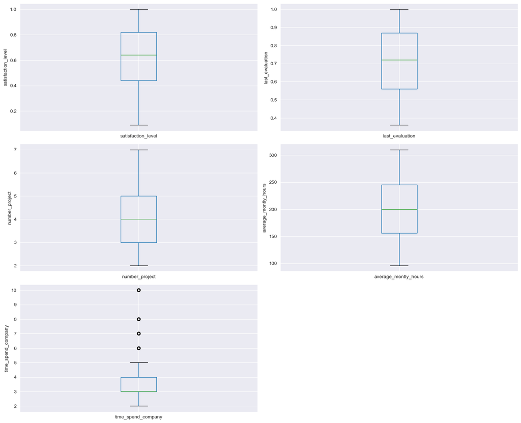

```python
plt.figure(figsize=(15, 20))

# List of columns to plot
columns = ['satisfaction_level', 'last_evaluation', 'number_project',
       'average_montly_hours', 'time_spend_company']

# Loop through the columns and create a subplot for each
for i, column in enumerate(columns, 1):
    plt.subplot(5, 2, i)
    fig = df.boxplot(column=column)
    fig.set_title('')
    fig.set_ylabel(column)

# Show the plot
plt.tight_layout()
plt.show()
```

The above boxplots confirm that there are **outliers** in time_spend_company

**Check the distribution of variables**

Now, We will plot the histograms to check distributions to find out if they are normal or skewed. If the variable follows normal distribution, then we will do Extreme Value Analysis otherwise if they are skewed, we will find IQR (Interquantile range).

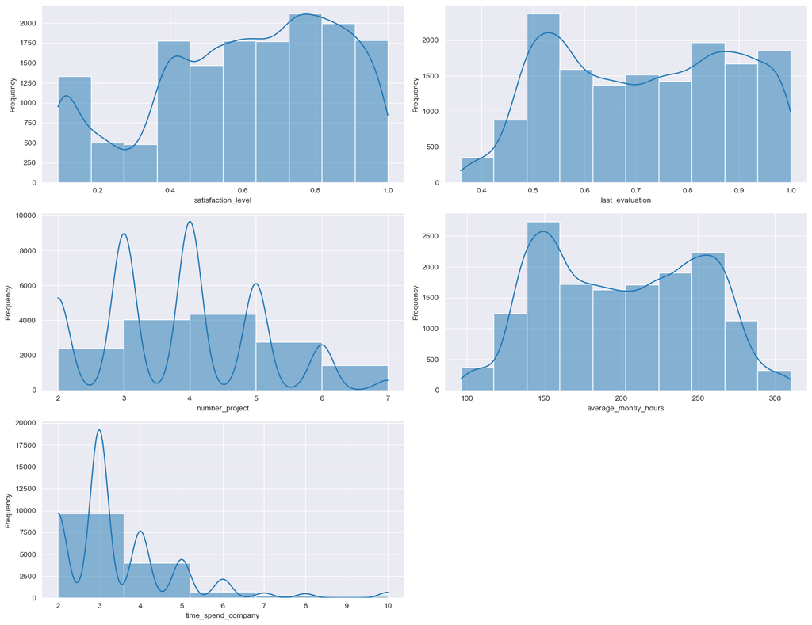

```python
plt.figure(figsize=(15, 15))
columns = ['satisfaction_level', 'last_evaluation', 'number_project',
       'average_montly_hours', 'time_spend_company']

for i, column in enumerate(columns, 1):
    plt.subplot(4, 2, i)
    if column == 'number_project' or column == 'time_spend_company':
        sns.histplot(df[column], bins=5, kde=True)
    else:
        sns.histplot(df[column], bins=10, kde=True)
    plt.xlabel(column)
    plt.ylabel('Frequency')

plt.tight_layout()
plt.show()
```

```python
numerical_columns = ['satisfaction_level', 'last_evaluation', 'number_project','average_montly_hours', 'time_spend_company']

# Compute skewness
skewness = df[numerical_columns].skew()

# Display skewness
print("Skewness of numerical variables:")
print(skewness)
```

```
Skewness of numerical variables:
satisfaction_level     -0.476360
last_evaluation        -0.026622
number_project          0.337706
average_montly_hours    0.052842
time_spend_company      1.853319
dtype: float64
```

We can see that time_spend_company is right skewed and skewness is high(1.85), so we have to apply log transformation. If then we find outliers there, we have to cap the outliers by setting them to the nearest acceptable value. This helps improve model performance by handling extreme values.

Compute the correlation matrix for only numerical columns

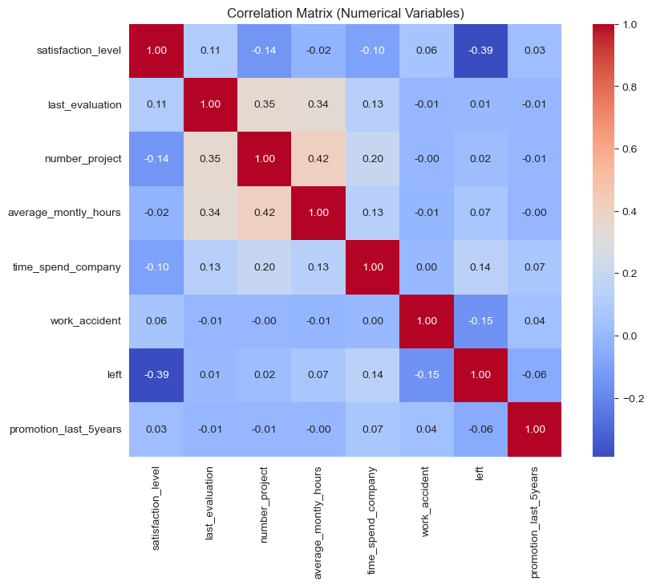

```python
numeric_df = df.select_dtypes(include=['float64', 'int64'])
corr_matrix = numeric_df.corr()
plt.figure(figsize=(10, 7))
sns.heatmap(corr_matrix, annot=True, cmap='coolwarm', fmt='.2f', cbar=True, square=True)
plt.title('Correlation Matrix (Numerical Variables)')
plt.show()
```

Chi-square Test for categorical features in a dataset.

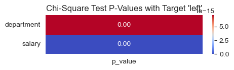

```python
from scipy.stats import chi2_contingency

def chi_square_test_with_target(df, target='left'):
    df_temp = df.copy()
    df_temp[target] = df_temp[target].astype('object')
    categorical_columns = df_temp.select_dtypes(include=['object']).columns.tolist()

    if target not in categorical_columns:
        raise ValueError(f"The target '{target}' is not a categorical column. Make sure it exists and is categorical.")

    p_values = {}
    for col in categorical_columns:
        if col != target:
            contingency_table = pd.crosstab(df_temp[col], df_temp[target])
            chi2, p, dof, expected = chi2_contingency(contingency_table)
            p_values[col] = p

    return p_values
p_values_dict = chi_square_test_with_target(df, target='left')
p_values_df = pd.DataFrame.from_dict(p_values_dict, orient='index', columns=['p_value'])
plt.figure(figsize=(5, len(p_values_df)/2))
sns.heatmap(p_values_df, annot=True, cmap='coolwarm', fmt='.2f', cbar=True, square=False)
plt.title("Chi-Square Test P-Values with Target 'left'")
plt.yticks(rotation=0)
plt.show()
```

# Data Preprocessing

```python
df.shape
```

```
(14999, 10)
```

```python
# Finding Duplicate rows
duplicates = df[df.duplicated()]
duplicates.shape
```

```
(3008, 10)
```

Here, we can clearly see there are 3008 **duplicate** rows, we should drop them.

```python
df_unique = df.drop_duplicates()
df = df_unique
```

```python
df.shape
```

```
(11991, 10)
```

```python
# Declare feature vector and target variable
X = df.drop(['left'], axis=1)
y = df['left']
```

```python
# Split data into separate training and test set
from sklearn.model_selection import train_test_split

X_train, X_test, y_train, y_test = train_test_split(X, y, test_size=0.2, random_state=42)
```

Upon conducting a thorough analysis of the dataset, we have determined that both the numerical and categorical variables do not contain any missing or null values. Therefore, no further action is required in terms of handling missing data

In this analysis, data preprocessing was meticulously conducted to prepare the datasets for modeling. The following techniques were applied **separately** to the **training** and **test** datasets to ensure data integrity and prevent data leakage:

1. **Log Transformation**
   - **Training Set**: Applied to skewed numerical features to stabilize variance and normalize their distribution.
   - **Test Set**: Applied the same log transformation using parameters derived from the training data.
2. **Outlier Capping**
   - **Training Set**:
     - Calculated outlier thresholds using statistical measures.
     - Capped extreme values based on these thresholds.
   - **Test Set**:
     - Applied the same upper and lower bounds derived from the training set to cap outliers, ensuring consistency.
3. **Encoding Categorical Variables**
   - **One-Hot Encoding**:
     - **Training Set**: Created binary indicators for nominal categorical features.
     - **Test Set**: Applied the same encoding scheme to handle categories consistently.
   - **Label Encoding**:
     - **Training Set**: Assigned integer values to ordinal categorical features based on category order.
     - **Test Set**: Applied the same label mappings to maintain consistency.
4. **Feature Scaling**
   - **Training Set**:
     - Performed feature scaling (StandardScaler) to standardize the range of numerical features.
     - Fitted the scaler on the training data to capture scaling parameters.
   - **Test Set**:
     - Applied the fitted scaler from the training set to transform the test data, ensuring scaling consistency.

Upon analyzing the distribution of the 'time_spend_company' column, we observed a right skewness. To address this, we will apply a logarithmic transformation to normalize the distribution and improve the model's performance.

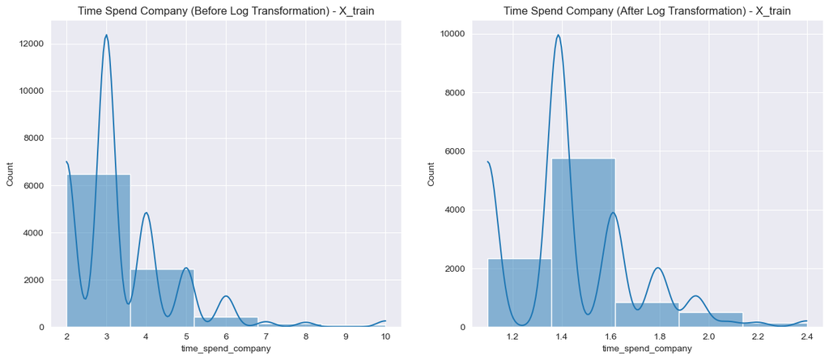

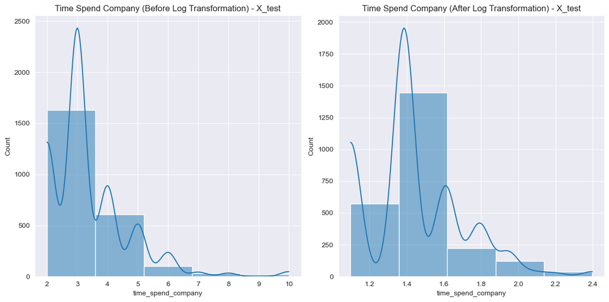

```python
plt.figure(figsize=(15, 6))

plt.subplot(1, 2, 1)
sns.histplot(X_train['time_spend_company'], kde=True, bins=5)
plt.title('Time Spend Company (Before Log Transformation) - X_train')

# Apply log transformation to X_train
X_train['time_spend_company'] = np.log1p(X_train['time_spend_company'])

plt.subplot(1, 2, 2)
sns.histplot(X_train['time_spend_company'], kde=True, bins=5)
plt.title('Time Spend Company (After Log Transformation) - X_train')

# Visualize the same transformation in X_test
plt.figure(figsize=(12, 6))

plt.subplot(1, 2, 1)
sns.histplot(X_test['time_spend_company'], kde=True, bins=5)
plt.title('Time Spend Company (Before Log Transformation) - X_test')

# Apply log transformation to X_test (same transformation as X_train)
X_test['time_spend_company'] = np.log1p(X_test['time_spend_company'])

plt.subplot(1, 2, 2)
sns.histplot(X_test['time_spend_company'], kde=True, bins=5)
plt.title('Time Spend Company (After Log Transformation) - X_test')

plt.tight_layout()
plt.show()
```

```python
def calculate_fences(series, multiplier=1.5):
    Q1 = series.quantile(0.25)
    Q3 = series.quantile(0.75)
    IQR = Q3 - Q1
    lower_fence = Q1 - (multiplier * IQR)
    upper_fence = Q3 + (multiplier * IQR)
    return lower_fence, upper_fence

stag_lower_fence, stag_upper_fence = calculate_fences(X_train['time_spend_company'], multiplier=1.5)
print(f"time_spend_company outliers are values < {stag_lower_fence} or > {stag_upper_fence}")
```

```
time_spend_company outliers are values < 1.051579034148576 or > 1.9441532394054148
```

Here, eventhough we applied log transformation, we still have outliers in the 'time_spend_company' column. We will cap these outliers by setting them to the nearest acceptable value.

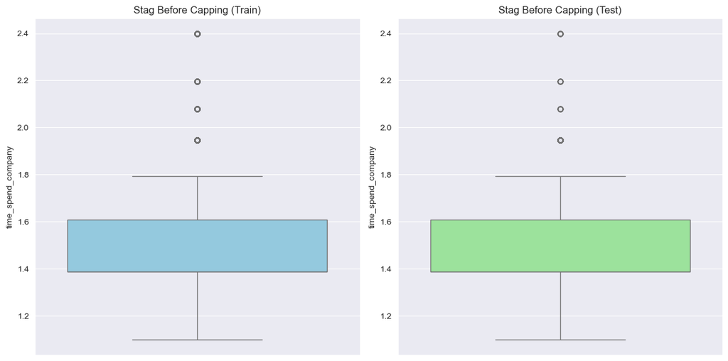

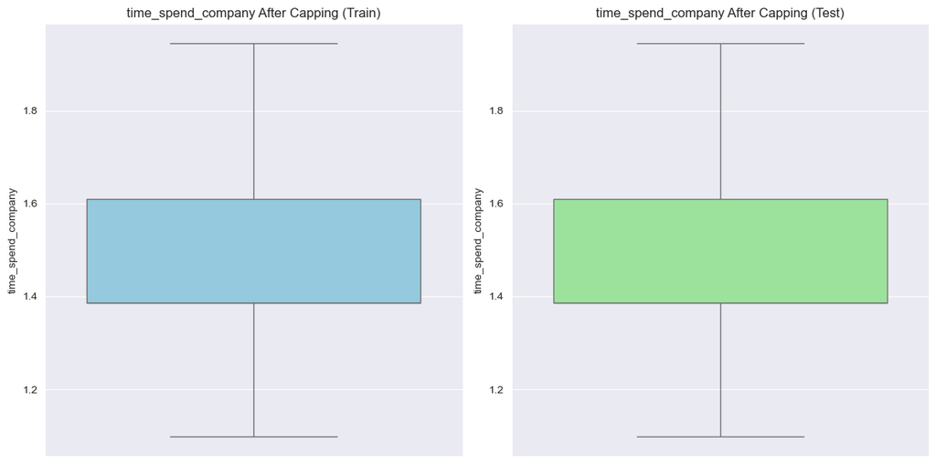

```python
def plot_boxplots(df_train, df_test, columns, titles):
    num_cols = len(columns)
    plt.figure(figsize=(12, 6))

    for i, col in enumerate(columns, 1):
        plt.subplot(1, num_cols * 2, i)
        sns.boxplot(y=df_train[col], color='skyblue')
        plt.title(f'{titles[i - 1]} (Train)')

        plt.subplot(1, num_cols * 2, i + num_cols)
        sns.boxplot(y=df_test[col], color='lightgreen')
        plt.title(f'{titles[i - 1]} (Test)')

    plt.tight_layout()
    plt.show()

columns = ['time_spend_company']
titles_before = ['Stag Before Capping']
plot_boxplots(X_train, X_test, columns, titles_before)

def cap_outliers(df, column, lower, upper):
    return df[column].clip(lower=lower, upper=upper)

X_train['time_spend_company'] = cap_outliers(X_train, 'time_spend_company', stag_lower_fence, stag_upper_fence)
X_test['time_spend_company'] = cap_outliers(X_test, 'time_spend_company', stag_lower_fence, stag_upper_fence)

titles_after = ['time_spend_company After Capping']
plot_boxplots(X_train, X_test, columns, titles_after)
```

```python
# Encode categorical variables
# Apply one hot encoding for department
from sklearn.preprocessing import OneHotEncoder
onehot_columns = ['department']
onehot_encoder = OneHotEncoder(drop='first', sparse_output=False)
X_train_onehot = onehot_encoder.fit_transform(X_train[onehot_columns])
X_test_onehot = onehot_encoder.transform(X_test[onehot_columns])
onehot_feature_names = onehot_encoder.get_feature_names_out(onehot_columns)
X_train_onehot_df = pd.DataFrame(X_train_onehot, columns=onehot_feature_names, index=X_train.index)
X_test_onehot_df = pd.DataFrame(X_test_onehot, columns=onehot_feature_names, index=X_test.index)
X_train = X_train.drop(columns=onehot_columns).join(X_train_onehot_df)
X_test = X_test.drop(columns=onehot_columns).join(X_test_onehot_df)
```

```python
# Apply label encoding for salary
salary_mapping = {'low': 1, 'medium': 2, 'high': 3}
X_train['salary'] = X_train['salary'].map(salary_mapping)
X_test['salary'] = X_test['salary'].map(salary_mapping)
```

```python
X_train.head()
```

|  | satisfaction_level | last_evaluation | number_project | average_montly_hours | time_spend_company | work_accident | promotion_last_5years | salary | department_RandD | department_accounting | department_hr | department_management | department_marketing | department_product_mng | department_sales | department_support | department_technical |
| --- | --- | --- | --- | --- | --- | --- | --- | --- | --- | --- | --- | --- | --- | --- | --- | --- | --- |
| 6426 | 0.86 | 0.56 | 5 | 141 | 1.098612 | 0 | 0 | 2 | 0.0 | 0.0 | 0.0 | 0.0 | 0.0 | 0.0 | 1.0 | 0.0 | 0.0 |
| 288 | 0.82 | 0.91 | 5 | 232 | 1.791759 | 0 | 0 | 1 | 0.0 | 0.0 | 0.0 | 0.0 | 0.0 | 0.0 | 0.0 | 0.0 | 1.0 |
| 5051 | 0.62 | 0.52 | 3 | 148 | 1.386294 | 0 | 0 | 2 | 0.0 | 0.0 | 0.0 | 0.0 | 0.0 | 0.0 | 1.0 | 0.0 | 0.0 |
| 11132 | 0.43 | 0.74 | 4 | 129 | 1.944153 | 0 | 0 | 2 | 0.0 | 0.0 | 1.0 | 0.0 | 0.0 | 0.0 | 0.0 | 0.0 | 0.0 |
| 3687 | 0.85 | 0.79 | 3 | 156 | 1.386294 | 0 | 0 | 2 | 0.0 | 0.0 | 0.0 | 0.0 | 0.0 | 0.0 | 1.0 | 0.0 | 0.0 |

```python
X_test.head()
```

|  | satisfaction_level | last_evaluation | number_project | average_montly_hours | time_spend_company | work_accident | promotion_last_5years | salary | department_RandD | department_accounting | department_hr | department_management | department_marketing | department_product_mng | department_sales | department_support | department_technical |
| --- | --- | --- | --- | --- | --- | --- | --- | --- | --- | --- | --- | --- | --- | --- | --- | --- | --- |
| 397 | 0.09 | 0.79 | 6 | 293 | 1.791759 | 0 | 0 | 1 | 0.0 | 0.0 | 0.0 | 0.0 | 0.0 | 0.0 | 1.0 | 0.0 | 0.0 |
| 3107 | 0.74 | 0.96 | 4 | 154 | 1.609438 | 0 | 0 | 2 | 0.0 | 0.0 | 0.0 | 0.0 | 0.0 | 0.0 | 0.0 | 1.0 | 0.0 |
| 9331 | 0.81 | 0.97 | 4 | 212 | 1.098612 | 0 | 0 | 1 | 0.0 | 0.0 | 0.0 | 0.0 | 0.0 | 0.0 | 1.0 | 0.0 | 0.0 |
| 357 | 0.37 | 0.54 | 2 | 149 | 1.386294 | 0 | 0 | 1 | 0.0 | 0.0 | 0.0 | 0.0 | 0.0 | 0.0 | 0.0 | 1.0 | 0.0 |
| 1326 | 0.10 | 0.77 | 6 | 272 | 1.609438 | 0 | 0 | 1 | 0.0 | 1.0 | 0.0 | 0.0 | 0.0 | 0.0 | 0.0 | 0.0 | 0.0 |

```python
X_train.shape, X_test.shape
```

```
((9592, 17), (2399, 17))
```

```python
# Feature Scaling
from sklearn.preprocessing import StandardScaler
columns = X_train.columns

scaler = StandardScaler()
X_train = scaler.fit_transform(X_train)
X_test = scaler.transform(X_test)

X_train = pd.DataFrame(X_train, columns=columns)
X_test = pd.DataFrame(X_test, columns=columns)
```

We now have X_train dataset ready to be fed into the Random Forest Classifier, and KNeighbors Classifier . we will do it as follows.

# Model Implementation

```python
print("Class distribution in y_train:")
print(y_train.value_counts())

print("\nClass distribution in y_test:")
print(y_test.value_counts())
```

```
Class distribution in y_train:
left
0    8002
1    1590
Name: count, dtype: int64

Class distribution in y_test:
left
0    1998
1     401
Name: count, dtype: int64
```

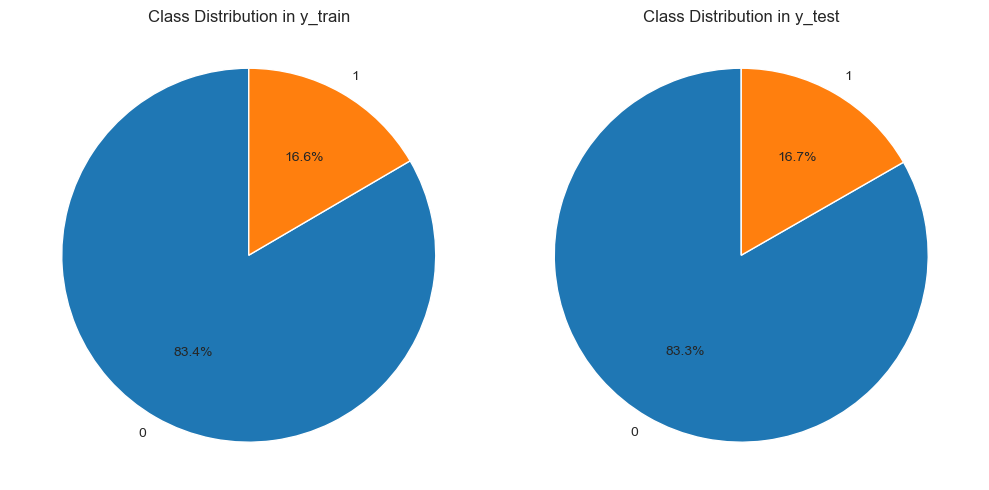

```python
plt.figure(figsize=(10,5))

plt.subplot(1, 2, 1)
y_train_value_counts = y_train.value_counts()
plt.pie(y_train_value_counts, labels=y_train_value_counts.index, autopct='%1.1f%%', startangle=90)
plt.title("Class Distribution in y_train")
plt.axis('equal')

plt.subplot(1, 2, 2)
y_test_value_counts = y_test.value_counts()
plt.pie(y_test_value_counts, labels=y_test_value_counts.index, autopct='%1.1f%%', startangle=90)
plt.title("Class Distribution in y_test")
plt.axis('equal')

plt.tight_layout()
plt.show()
```

The class distribution in both the training and test sets is imbalanced, with the majority class (0) having a significantly higher number of instances compared to the minority class (1). This imbalance can potentially affect the model's ability to predict the minority. So we will use F1-score as the evaluation metric to handle this situation.

## Random Forest Classifier

```python
from sklearn.ensemble import RandomForestClassifier
from sklearn.model_selection import GridSearchCV
from sklearn.metrics import f1_score, make_scorer

f1_scorer = make_scorer(f1_score, average='macro')
rf = RandomForestClassifier(random_state=0)
param_grid = {
    'n_estimators': [50, 100, 200],
    'max_depth': [None, 10, 20, 30],
    'min_samples_split': [2, 5, 10],
    'min_samples_leaf': [1, 2, 4],
    'max_features': ['auto', 'sqrt', 'log2'],
}

grid_search = GridSearchCV(
    estimator=rf,
    param_grid=param_grid,
    cv=5,
    n_jobs=-1,
    verbose=2,
    scoring=f1_scorer
)
grid_search.fit(X_train, y_train)
print(f"Best Hyperparameters: {grid_search.best_params_}")
print(f"Best Cross-validation F1-Score: {grid_search.best_score_}")
best_rf_model = grid_search.best_estimator_
y_pred_rf = best_rf_model.predict(X_test)
test_f1 = f1_score(y_test, y_pred_rf, average='macro')
```

```
Fitting 5 folds for each of 324 candidates, totalling 1620 fits
Best Hyperparameters: {'max_depth': 20, 'max_features': 'sqrt', 'min_samples_leaf': 1, 'min_samples_split': 2, 'n_estimators': 50}
Best Cross-validation F1-Score: 0.9722481073952631
```

The best cross-validation score obtained during this process was **0.9722**, indicating that the model performed with **97.22%** F1-Score on the validation folds during training.

## K-Nearest Neighbor(K-NN) Algorithm

```python
from sklearn.metrics import f1_score, make_scorer
from sklearn.neighbors import KNeighborsClassifier

knn = KNeighborsClassifier()
param_grid = {
    'n_neighbors': [3, 5, 7, 9, 11],
    'weights': ['uniform', 'distance'],
    'algorithm': ['auto', 'ball_tree', 'kd_tree', 'brute'],
    'p': [1, 2]
}
f1_scorer = make_scorer(f1_score, average='macro')
grid_search = GridSearchCV(
    estimator=knn,
    param_grid=param_grid,
    cv=5,
    n_jobs=-1,
    verbose=2,
    scoring=f1_scorer
)

grid_search.fit(X_train, y_train)
print(f"Best Hyperparameters: {grid_search.best_params_}")
print(f"Best Cross-validation F1-Score: {grid_search.best_score_:.4f}")
best_knn_model = grid_search.best_estimator_
y_pred_knn = best_knn_model.predict(X_test)
```

```
Fitting 5 folds for each of 80 candidates, totalling 400 fits
Best Hyperparameters: {'algorithm': 'auto', 'n_neighbors': 3, 'p': 1, 'weights': 'uniform'}
Best Cross-validation F1-Score: 0.9244
```

The best cross-validation score obtained during this process was **0.9244**, indicating that the model performed with **92.44%** F1-Score on the validation folds during training.

# Model Evaluation and Discussion.

Given the imbalanced distribution of our target variable, we will employ evaluation metrics such as **precision, recall, F1-score**, and the **Area Under the Receiver Operating Characteristic Curve** (AU-ROC) to accurately assess our model and calculate our model's performance.

## Confusion matrix

### Confusion Matrix for Random Forest Classifier

```python
from sklearn.metrics import confusion_matrix

cmr = confusion_matrix(y_test, y_pred_rf)
print('Confusion matrix for Random Forest Classifier\n\n', cmr)
print('\nTrue Positives(TP) = ', cmr[0,0])
print('True Negatives(TN) = ', cmr[1,1])
print('False Positives(FP) = ', cmr[0,1])
print('False Negatives(FN) = ', cmr[1,0])
```

```
Confusion matrix for Random Forest Classifier

 [[1991    7]
 [  44  357]]

True Positives(TP) =  1991
True Negatives(TN) =  357
False Positives(FP) =  7
False Negatives(FN) =  44
```

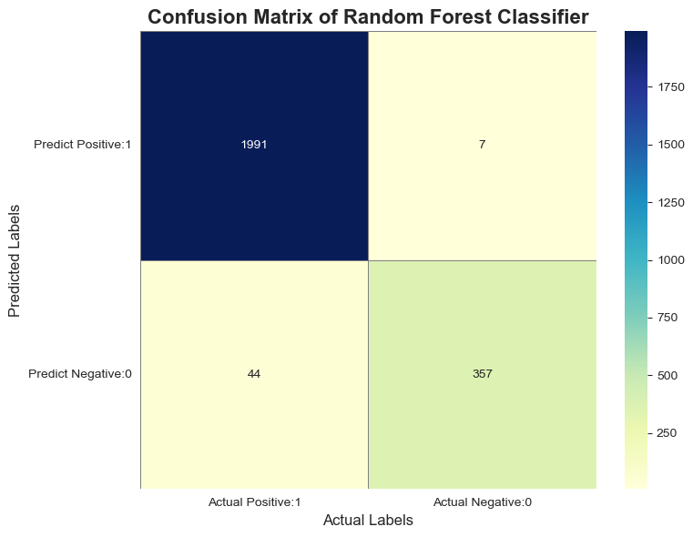

```python
cmr_matrix = pd.DataFrame(
    data=cmr,
    columns=['Actual Positive:1', 'Actual Negative:0'],
    index=['Predict Positive:1', 'Predict Negative:0']
)
plt.figure(figsize=(8, 6))
sns.heatmap(cmr_matrix, annot=True, fmt='d', cmap='YlGnBu', linewidths=.5, linecolor='gray')
plt.title('Confusion Matrix of Random Forest Classifier', fontsize=16, weight='bold')
plt.xlabel('Actual Labels', fontsize=12)
plt.ylabel('Predicted Labels', fontsize=12)
plt.xticks(rotation=0)
plt.yticks(rotation=0)
plt.tight_layout()
plt.show()
```

### Confusion Matrix for K-Nearest Neighbor Classifier

```python
cmk = confusion_matrix(y_test, y_pred_knn)
print('Confusion matrix for K-Nearest Neighbor classifier\n\n', cmk)
print('\nTrue Positives(TP) = ', cmk[0,0])
print('True Negatives(TN) = ', cmk[1,1])
print('False Positives(FP) = ', cmk[0,1])
print('False Negatives(FN) = ', cmk[1,0])
```

```
Confusion matrix for K-Nearest Neighbor classifier

 [[1925   73]
 [  48  353]]

True Positives(TP) =  1925
True Negatives(TN) =  353
False Positives(FP) =  73
False Negatives(FN) =  48
```

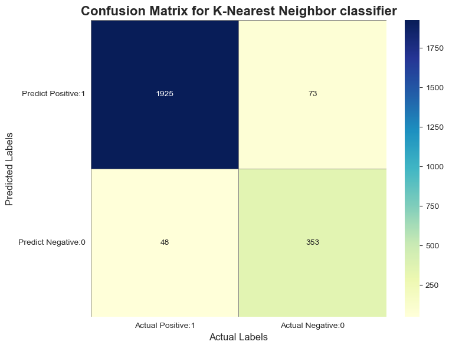

```python
cmk_matrix = pd.DataFrame(
    data=cmk,
    columns=['Actual Positive:1', 'Actual Negative:0'],
    index=['Predict Positive:1', 'Predict Negative:0']
)
plt.figure(figsize=(8, 6))
sns.heatmap(cmk_matrix, annot=True, fmt='d', cmap='YlGnBu', linewidths=.5, linecolor='gray')
plt.title('Confusion Matrix for K-Nearest Neighbor classifier', fontsize=16, weight='bold')
plt.xlabel('Actual Labels', fontsize=12)
plt.ylabel('Predicted Labels', fontsize=12)
plt.xticks(rotation=0)
plt.yticks(rotation=0)
plt.tight_layout()
plt.show()
```

- The model seems to be doing well on the majority class (0), as it correctly identifies a high number of true negatives (353) and true positives (1925).
- However, the model seems to struggle with the minority class (1), with 48 false negatives (FN) and 73 false positives (FP), which can be problematic when dealing with imbalanced datasets. The presence of false positives and false negatives suggests that the model is not perfect in distinguishing between the two classes.

## Classification Report

### Classification Report for Random Forest Classifier

```python
from sklearn.metrics import classification_report

print(classification_report(y_test, y_pred_rf))
```

```
              precision    recall  f1-score   support

           0       0.98      1.00      0.99      1998
           1       0.98      0.89      0.93       401

    accuracy                           0.98      2399
   macro avg       0.98      0.94      0.96      2399
weighted avg       0.98      0.98      0.98      2399
```

**Performance Insights**

### Classification Report for K-Nearest Neighbor Classifier

```python
print(classification_report(y_test, y_pred_knn))
```

```
              precision    recall  f1-score   support

           0       0.98      0.96      0.97      1998
           1       0.83      0.88      0.85       401

    accuracy                           0.95      2399
   macro avg       0.90      0.92      0.91      2399
weighted avg       0.95      0.95      0.95      2399
```

## AU-ROC Curve

### AU-ROC Curve for Random Forest Classifier

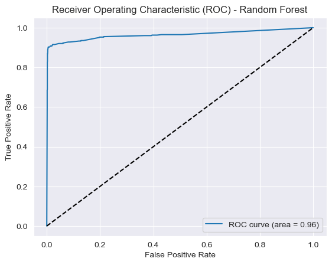

```python
from sklearn.metrics import roc_auc_score, roc_curve
import matplotlib.pyplot as plt

roc_auc = roc_auc_score(y_test, best_rf_model.predict_proba(X_test)[:,1])
fpr, tpr, thresholds = roc_curve(y_test, best_rf_model.predict_proba(X_test)[:,1])

plt.figure()
plt.plot(fpr, tpr, label=f'ROC curve (area = {roc_auc:.2f})')
plt.plot([0, 1], [0, 1], 'k--')
plt.xlabel('False Positive Rate')
plt.ylabel('True Positive Rate')
plt.title('Receiver Operating Characteristic (ROC) - Random Forest')
plt.legend(loc='lower right')
plt.show()
```

### AU-ROC Curve for K-Nearest Neighbor Classifier

[figure not shown]

```python
from sklearn.metrics import roc_auc_score, roc_curve
import matplotlib.pyplot as plt

roc_auc = roc_auc_score(y_test, best_knn_model.predict_proba(X_test)[:,1])
fpr, tpr, thresholds = roc_curve(y_test, best_rf_model.predict_proba(X_test)[:,1])

plt.figure()
plt.plot(fpr, tpr, label=f'ROC curve (area = {roc_auc:.2f})')
plt.plot([0, 1], [0, 1], 'k--')
plt.xlabel('False Positive Rate')
plt.ylabel('True Positive Rate')
plt.title('Receiver Operating Characteristic (ROC) - K-Nearest Neighbor')
plt.legend(loc='lower right')
plt.show()
```

**Comments**

- AU-ROC is a single number summary of classifier performance. The higher the value, the better the classifier.
- AU-ROC of our model approaches towards 1. So, we can conclude that our both classifiers do a good job at different thresholds in predicting whether employee left the company or not

# Conclusion

Two classification models, a K-Nearest Neighbors (KNN) classifier and a Random Forest classifier, were evaluated on a dataset with an imbalanced target variable. The following metrics were considered: accuracy, AU-ROC (Area Under the ROC Curve), precision, recall, F1-score, as well as macro averages, which treat all classes equally regardless of their frequency.

**Overall Performance**

Random Forest Classifier:

- Best Cross-validation macro F1-score: 0.97
- AU-ROC: 0.96
- Test Accuracy: 0.98
- Test Macro Avg Precision: 0.98
- Test Macro Avg Recall: 0.94
- Test Macro Avg F1-score: 0.96

K-Nearest Neighbors Classifier:

- Best Cross-validation macro F1-score: 0.92
- AU-ROC: 0.94
- Test Accuracy: 0.95
- Test Macro Avg Precision: 0.90
- Test Macro Avg Recall: 0.92
- Test Macro Avg F1-score: 0.91

The Random Forest classifier demonstrates higher accuracy, AU-ROC, and macro-average metrics compared to the KNN classifier. Notably, the Random Forest achieves a best cross-validation macro F1-score of approximately 0.97, outperforming KNN’s best of around 0.92. Additionally, the Random Forest has a higher AU-ROC score of 0.96 compared to KNN’s 0.94, indicating a better overall ability to discriminate between classes, particularly in the case of imbalanced datasets.

These macro-averaged values highlight the Random Forest’s balanced capability to handle both majority and minority classes effectively. In imbalanced settings, its ensemble nature allows it to identify subtle patterns that simpler models, like KNN, may miss, especially when minority class instances are sparse. The AU-ROC score further emphasizes the Random Forest’s superior performance in distinguishing between classes across various decision thresholds.

The Random Forest’s ensemble approach tends to be more resilient in imbalanced settings and can better identify subtle patterns. KNN, while simpler, can suffer when the minority class instances are sparse or not well represented in the feature space. Both models demonstrated strong generalization performance during cross-validation, with no indications of overfitting, as evidenced by consistent results across training and validation folds. The Random Forest also allows for feature importance analysis, aiding in interpretability and guiding potential improvements in data collection or feature engineering.

In summary, both models demonstrate strong capabilities on this dataset. However, the Random Forest classifier outperforms the KNN classifier, particularly in terms of minority class handling, AU-ROC, and balanced performance as evidenced by higher macro-averaged metrics. Given these results, the **Random Forest classifier is the recommended model** for this imbalanced classification task.

# References

The work done in this project is inspired from following books and websites

1. Hands on Machine Learning with Scikit-Learn and Tensorflow by Aurélién Géron
2. Introduction to Machine Learning with Python by Andreas C. Müller and Sarah Guido
3. Udemy course – Machine Learning – A Z by Kirill Eremenko and Hadelin de Ponteves
4. Udemy course – Feature Engineering for Machine Learning by Soledad Galli
5. Udemy course – Feature Selection for Machine Learning by Soledad Galli
6. https://www.geeksforgeeks.org/k-nearest-neighbours/
7. https://www.analyticsvidhya.com/blog/2020/10/feature-selection-techniques-in-machine-learning/